# TMS WM Analysis

## Confidence Intervals and PSVE

### Point estimate confint

```r
summary(m0)
```

```
## Generalized linear mixed model fit by maximum likelihood (Laplace
##   Approximation) [glmerMod]
##  Family: binomial  ( logit )
## Formula: correctness ~ TMS_Type + coding_section_no + (1 | participant_id) +
##     (1 | problem_id) + (1 | participant_id:TMS_Type)
##    Data: data
##
##      AIC      BIC   logLik deviance df.resid
##    472.3    497.9   -230.1    460.3      527
##
## Scaled residuals:
##     Min      1Q  Median      3Q     Max
## -3.3104 -0.1738  0.1997  0.3948  3.2388
##
## Random effects:
##  Groups                  Name        Variance Std.Dev.
##  participant_id:TMS_Type (Intercept) 1.186    1.0888
##  participant_id          (Intercept) 0.768    0.8764
##  problem_id              (Intercept) 6.214    2.4928
## Number of obs: 533, groups:
## participant_id:TMS_Type, 54; participant_id, 27; problem_id, 24
##
## Fixed effects:
##                   Estimate Std. Error z value Pr(>|z|)
## (Intercept)        0.07388    0.70897   0.104 0.917000
## TMS_TypeWM        -0.22150    0.41829  -0.530 0.596423
## coding_section_no  0.61185    0.18536   3.301 0.000964 ***
## ---
## Signif. codes:  0 '***' 0.001 '**' 0.01 '*' 0.05 '.' 0.1 ' ' 1
##
## Correlation of Fixed Effects:
##             (Intr) TMS_TW
## TMS_TypeWM  -0.297
## cdng_sctn_n -0.473 -0.003
```

```r
pp0 = profile(m0)
```

```r
confint(pp0)
```

```
##                        2.5 %    97.5 %
## .sig01             0.5376908 1.8074948
## .sig02             0.0000000 1.6099218
## .sig03             1.7167084 3.7817997
## (Intercept)       -1.3641007 1.5063538
## TMS_TypeWM        -1.0763747 0.6481248
## coding_section_no  0.2562715 0.9858146
```

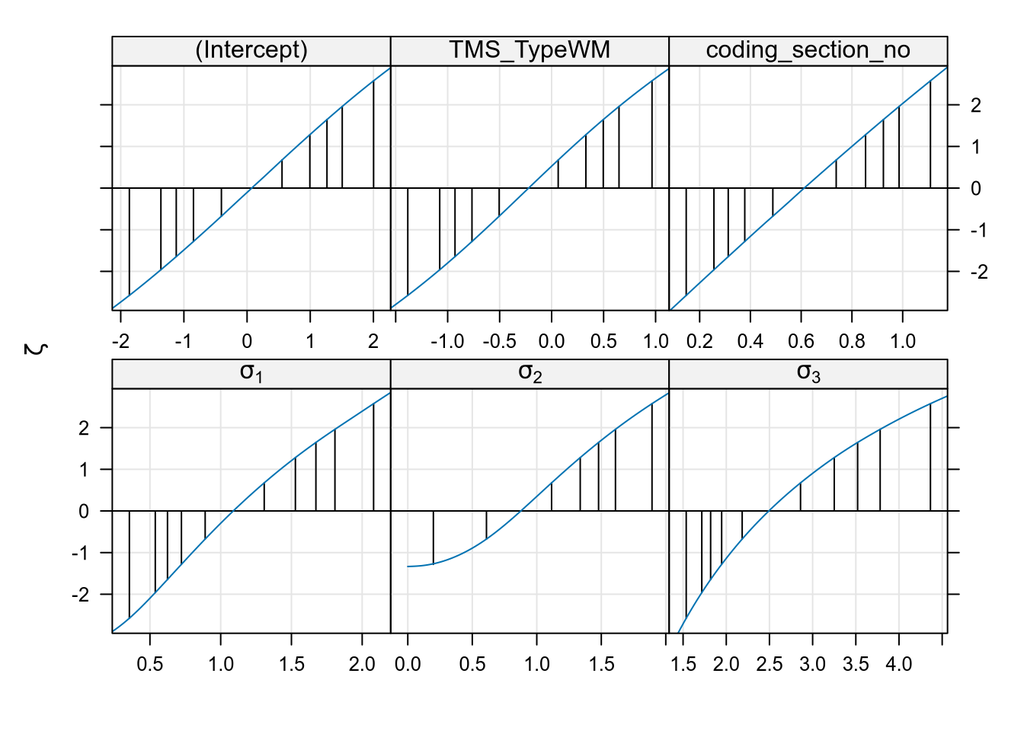

```r
xyplot(pp0)
```

$\sigma_1$ excludes zero, so this further confirms the likelihood ratio test above.

### Percentage of Structural Variance Explained

For the structural ICC statistic presented in the paper, see the separate bootstrapping scripts in `arm_2_bootstrap/`. This PSVE statistic is fine for looking at one experiment in isolation, but is problematic for comparing between different experiments with different stimulus variance (e.g., our two study arms, discussed in Section 4.2.3).

```r
# Simple thread-safe append function
safe_write <- function(row, fout, lock_file) {
  lck <- lock(lock_file) # Acquire lock
  # on.exit(unlock(lck))  # Ensure unlock on finish or error

  sink(
    file = fout,
    append = TRUE,
    type = "output",
    split = FALSE
  )
  cat(row, " \n")
  sink()
  unlock(lck) # Release lock
}
```

```r
# Callback function for each bootstrap simulation
get_psve <- function(m, effect, save = FALSE, fout, effect_order, f_lock) {
  # m is a glmer object so residual variance isn"t well-defined, hence "structural"
  # Store variance estimates for all random effects
  random_effects <- as.data.frame(VarCorr(m)) %>%
    rename(Groups = grp, Name = var1, Variance = vcov, Std.Dev. = sdcor) %>%
    select(-var2)

  num <- (random_effects %>% filter(Groups == effect))$Variance
  denom <- sum(random_effects$Variance)

  if (save) {
    if (missing(fout) || missing(effect_order)) {
      warning(sprintf(
        paste0(
          "get_psve(m, effect=%s, save=TRUE) failed to save: ",
          "fout or effect_order not provided"
        ),
        effect
      ))
    } else {
      vv <- sapply(effect_order, function(eff) {
        (random_effects %>% filter(Groups == eff))$Variance
      }) # this is to ensure that they appear in the same order every time
      safe_write(paste0(vv, collapse = ", "), fout, f_lock)
    }
  }

  return(c(num / denom))
}

get_psve(m0, "participant_id:TMS_Type")
```

```
## [1] 0.1451535
```

```r
#tmp <- as.data.frame(VarCorr(m0))
#tmp$grp
VarCorr(m0)
```

```
##  Groups                  Name        Std.Dev.
##  participant_id:TMS_Type (Intercept) 1.08885
##  participant_id          (Intercept) 0.87636
##  problem_id              (Intercept) 2.49284
```

### PSVE confint

Of the three significance tests here, this one (bootstrapping) is the most robust when `nsim` is big enough. [source](https://stats.stackexchange.com/questions/351164/confidence-intervals-for-glmm-bootstrap-vs-likelihood-profile/351171#351171), [source](https://www.ssc.wisc.edu/sscc/pubs/MM/MM_TestEffects.html#test-of-random-parameters)

```r
ordered_factors <- as.data.frame(VarCorr(m0))$grp
nsim <- 10000
# 10k sims took about 2.5 hrs

psve_log <- sprintf("%s/psve_bootstrap_%i.csv", correctness_outputdir, nsim)
file.create(psve_log)
```

```
## [1] TRUE
```

```r
lock_file <- paste0(psve_log, ".lock") # Define a lock file
cat(psve_log, "\n")
```

```
## /data1/eshedden/umich/tms_journal/SE-TMS-2026/arm_2/data-analysis/data-analysis-scripts/../candidate-models/regression-models-programming/FITB_v9-2_acc_model_summaries/psve_bootstrap_10000.csv
```

```r
# write the header
cat(paste0(ordered_factors, collapse = ","), "\n", file = psve_log)

b0 <- bootMer(
  m0,
  FUN = function(m) {
    get_psve(
      m,
      "participant_id:TMS_Type",
      save = TRUE,
      psve_log,
      ordered_factors,
      lock_file
    )
  },
  nsim = nsim,
  #.progress = "txt"
  parallel = "multicore",
  ncpus = 64
)
```

```r
quantile(b0$t, c(0.025, 0.975))
```

```
##         2.5%        97.5%
## 4.684757e-10 3.185672e-01
```

```r
bootstrap_sims <- read.csv(psve_log)
bootstrap_sims$sum <- rowSums(bootstrap_sims)
bootstrap_sims$psve <- bootstrap_sims$participant_id.TMS_Type / bootstrap_sims$sum
bootstrap_sims <- bootstrap_sims %>% arrange(psve)
bootstrap_sims %>% head(50)
```

```
##    participant_id.TMS_Type participant_id problem_id       sum         psve
## 1             0.000000e+00      0.9697046   4.218357  5.188062 0.000000e+00
## 2             0.000000e+00      1.7563570   8.003979  9.760336 0.000000e+00
## 3             0.000000e+00      0.2491450   3.666383  3.915528 0.000000e+00
## 4             0.000000e+00      0.9136201   3.577434  4.491055 0.000000e+00
## 5             0.000000e+00      2.4406112  11.680584 14.121195 0.000000e+00
## 6             0.000000e+00      0.2711874   4.758704  5.029892 0.000000e+00
## 7             0.000000e+00      1.2730507   5.323682  6.596732 0.000000e+00
## 8             0.000000e+00      1.3242959   6.567936  7.892232 0.000000e+00
## 9             0.000000e+00      3.1901985  10.268741 13.458939 0.000000e+00
## 10            0.000000e+00      1.0483765   6.329148  7.377525 0.000000e+00
## 11            0.000000e+00      0.4575165   3.096471  3.553987 0.000000e+00
## 12            0.000000e+00      3.5722192  22.266564 25.838783 0.000000e+00
## 13            0.000000e+00      1.3774474   5.506844  6.884291 0.000000e+00
## 14            0.000000e+00      0.9406444   8.908194  9.848838 0.000000e+00
```

[output cut: 36 more lines]

```r
quantile(bootstrap_sims$participant_id.TMS_Type, c(0.025, 0.975))
```

```
##         2.5%        97.5%
## 3.419113e-09 2.426873e+00
```

```r
quantile(bootstrap_sims$psve, c(0.025, 0.975))
```

```
##         2.5%        97.5%
## 4.690768e-10 3.185595e-01
```

```r
bottom_percentile <- 3
bottom_percentile_idx <- (nsim * bottom_percentile / 100)
```

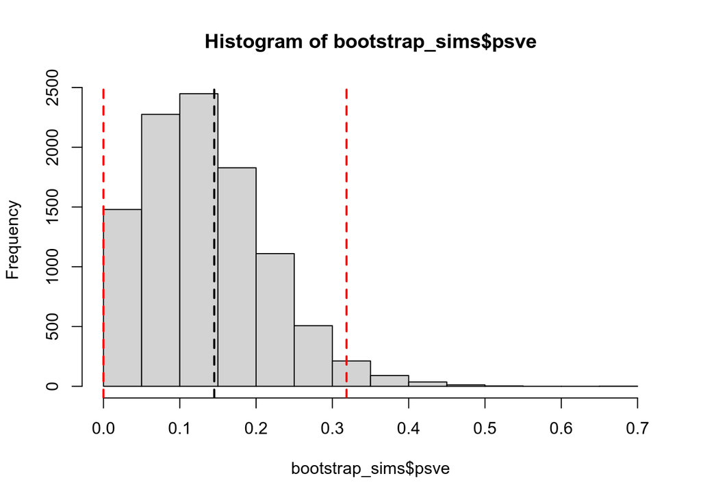

```r
# Distribution
hist(bootstrap_sims$psve, breaks=20, right=FALSE)
abline(v = quantile(b0$t, 0.025), col = "red", lwd = 2, lty = 2) # 2.5 percentile
abline(v = get_psve(m0, "participant_id:TMS_Type"), col = "black", lwd = 2, lty = 2) # estimate
abline(v = quantile(b0$t, 0.975), col = "red", lwd = 2, lty = 2) # 97.5 percentile
```

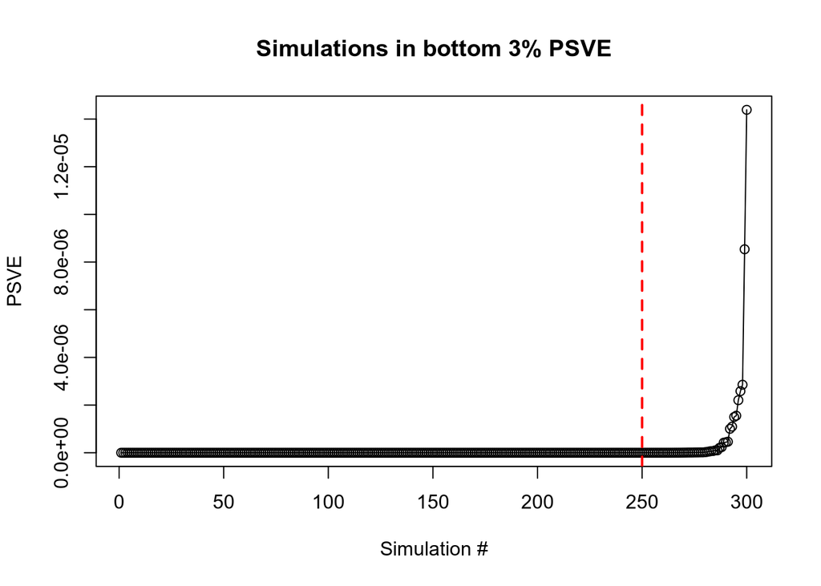

```r
# Low-PSVE simulations
plot(bootstrap_sims[1:bottom_percentile_idx,]$psve,
     type="o",
     main=sprintf('Simulations in bottom %d%% PSVE',
                  bottom_percentile),
     xlab='Simulation #',
     ylab='PSVE')
abline(v = 0.025*nsim, col = "red", lwd = 2, lty = 2) # 2.5 percentile
```

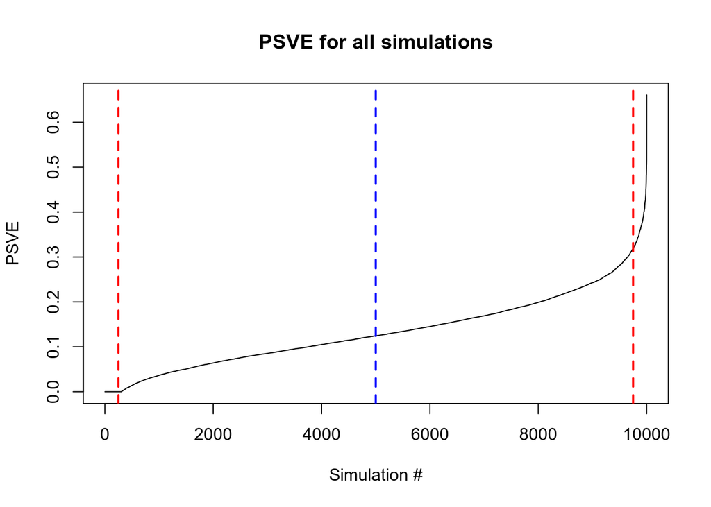

```r
# All simulations
plot(bootstrap_sims$psve,
     type="l",
     main='PSVE for all simulations',
     xlab='Simulation #',
     ylab='PSVE')
abline(v = 0.025*nsim, col = "red", lwd = 2, lty = 2) # 2.5 percentile
abline(v = nsim/2, col = "blue", lwd = 2, lty = 2) # median
abline(v = 0.975*nsim, col = "red", lwd = 2, lty = 2) # 97.5 percentile
```

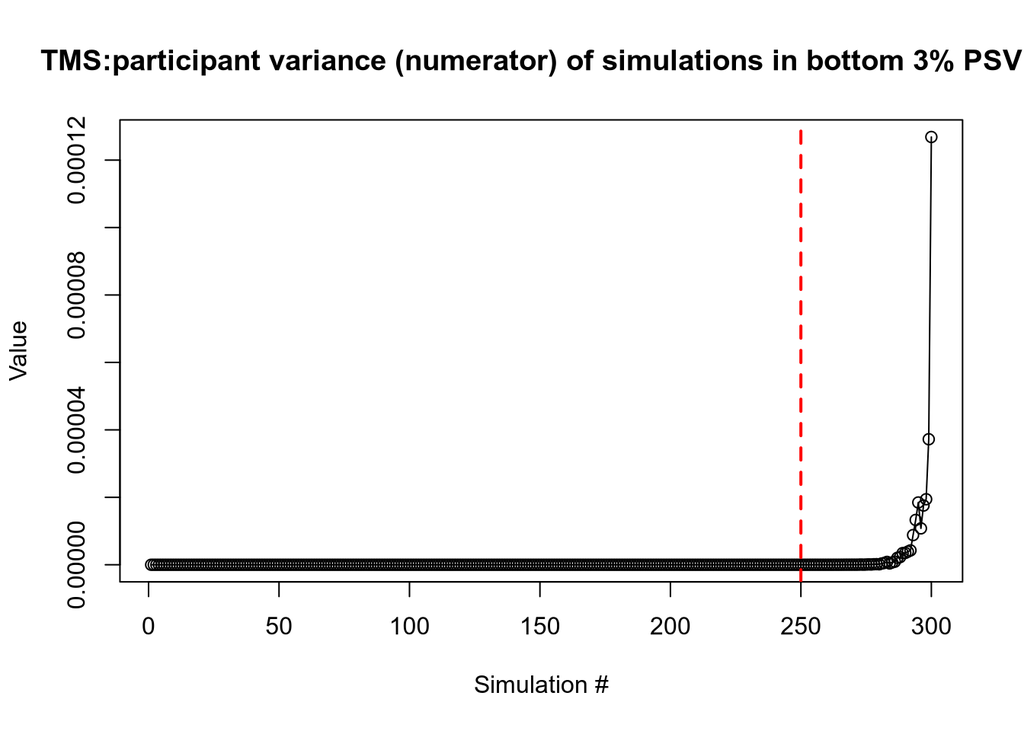

```r
# Num and denom in low-PSVE simulations
plot(bootstrap_sims[1:bottom_percentile_idx,]$participant_id.TMS_Type,
     type="o",
     main=sprintf('TMS:participant variance (numerator) of simulations in bottom %d%% PSVE', bottom_percentile),
     xlab='Simulation #',
     ylab='Value')
abline(v = 0.025*nsim, col = "red", lwd = 2, lty = 2) # 2.5 percentile
```

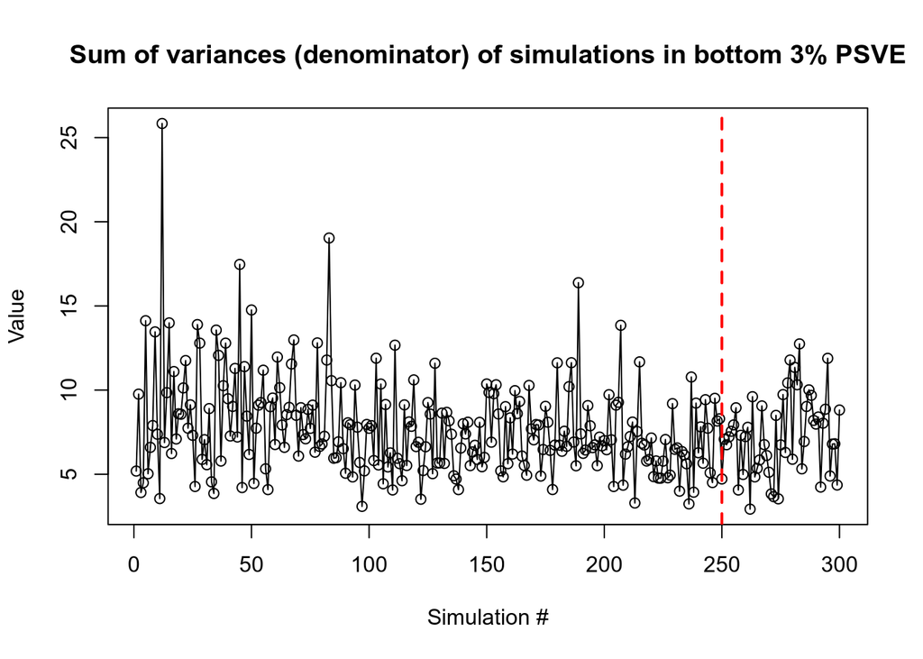

```r
plot(bootstrap_sims[1:bottom_percentile_idx,]$sum,
     type="o",
     main=sprintf('Sum of variances (denominator) of simulations in bottom %d%% PSVE', bottom_percentile),
     xlab='Simulation #',
     ylab='Value')
abline(v = 0.025*nsim, col = "red", lwd = 2, lty = 2) # 2.5 percentile
```

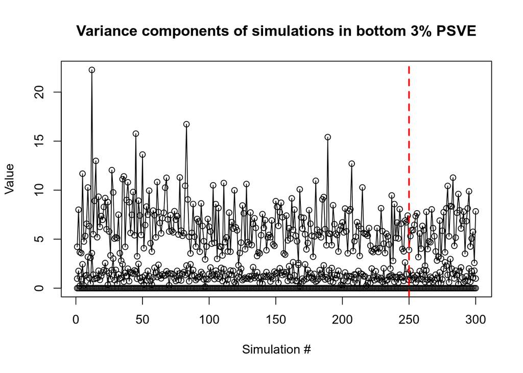

```r
# Component variances in low-PSVE simulations
all_y_values <- c(
  bootstrap_sims[1:bottom_percentile_idx,]$participant_id.TMS_Type,
  bootstrap_sims[1:bottom_percentile_idx,]$participant_id,
  bootstrap_sims[1:bottom_percentile_idx,]$problem_id)
y_range <- range(all_y_values)

plot(bootstrap_sims[1:bottom_percentile_idx,]$participant_id.TMS_Type,
     type="o",
     ylim=y_range,
     main=sprintf('Variance components of simulations in bottom %d%% PSVE', bottom_percentile),
     xlab='Simulation #',
     ylab='Value')
lines(bootstrap_sims[1:bottom_percentile_idx,]$participant_id, type="o")
lines(bootstrap_sims[1:bottom_percentile_idx,]$problem_id, type="o")
abline(v = 0.025*nsim, col = "red", lwd = 2, lty = 2) # 2.5 percentile
```

## Test other model candidates

For completeness, we will try the likelihood ratio test with all low-AIC model formulas.

```r
best_AIC <- correctness_models_da[order(correctness_models_da$AIC),]$AIC[[1]]
best_AIC
```

```
## [1] 472.2529
```

```r
AIC_candidates <- correctness_models_da[correctness_models_da$AIC < best_AIC + 3,]
AIC_candidates <- AIC_candidates[order(AIC_candidates$AIC),]
AIC_candidates
```

```
## # A tibble: 3 × 3
##   formula                                                              AIC   BIC
##   <chr>                                                              <dbl> <dbl>
## 1 correctness ~ TMS_Type + coding_section_no + (1|participant_id) +…  472.  498.
## 2 correctness ~ TMS_Type * coding_section_no + (1|participant_id) +…  474.  504.
## 3 correctness ~ TMS_Type + coding_section_no + (1|participant_id) +…  474.  504.
```

```r
# formulas with TMS fixed effect
has_TMS <- grepl('TMS_Type ', AIC_candidates$formula, fixed = TRUE)

add_fixed_TMS <- paste0(AIC_candidates$formula, ' + TMS_Type')
AIC_candidates$fixed_TMS_full <- ifelse(
  has_TMS, AIC_candidates$formula, add_fixed_TMS)

AIC_candidates$fixed_TMS_reduced <- str_remove_all(
  AIC_candidates$formula, fixed('TMS_Type + '))
AIC_candidates$fixed_TMS_reduced <- str_remove_all(
  AIC_candidates$fixed_TMS_reduced, fixed('TMS_Type * '))

AIC_candidates$fixed_TMS_reduced <- str_remove_all(
  AIC_candidates$fixed_TMS_reduced, fixed(' + (1|participant_id:TMS_Type)'))
AIC_candidates$fixed_TMS_reduced <- str_remove_all(
  AIC_candidates$fixed_TMS_reduced, fixed(' + (1|problem_id:TMS_Type)'))
# unsure whether (1|participant_id:TMS_Type) should be removed in the reduced version
```

```r
# debugging
for (f in AIC_candidates$fixed_TMS_full){
  cat(f, '\n')
}
```

```
## correctness ~ TMS_Type + coding_section_no + (1|participant_id) + (1|problem_id) + (1|participant_id:TMS_Type)
## correctness ~ TMS_Type * coding_section_no + (1|participant_id) + (1|problem_id) + (1|participant_id:TMS_Type)
## correctness ~ TMS_Type + coding_section_no + (1|participant_id) + (1|problem_id) + (1|participant_id:TMS_Type) + (1|problem_id:TMS_Type)
```

```r
cat('\n\n')
```

```r
for (f in AIC_candidates$fixed_TMS_reduced){
  cat(f, '\n')
}
```

```
## correctness ~ coding_section_no + (1|participant_id) + (1|problem_id)
## correctness ~ coding_section_no + (1|participant_id) + (1|problem_id)
## correctness ~ coding_section_no + (1|participant_id) + (1|problem_id)
```

```r
AIC_candidates$fixed_TMS_pval <- -1.0
for (i in seq_len(nrow(AIC_candidates))) {
  m_full <- glmer(
    AIC_candidates$fixed_TMS_full[i],
    data = data,
    family = binomial
  )
  m_reduced <- glmer(
    AIC_candidates$fixed_TMS_reduced[i],
    data = data,
    family = binomial
  )
  a <- anova(m_full, m_reduced)
  p_val <- a$"Pr(>Chisq)"[2]
  #print(p_val)
  AIC_candidates$fixed_TMS_pval[i] <- p_val
}
```

```
## boundary (singular) fit: see help('isSingular')
```

```r
AIC_candidates[AIC_candidates$fixed_TMS_pval < 0.05,]
```

```
## # A tibble: 3 × 6
##   formula              AIC   BIC fixed_TMS_full fixed_TMS_reduced fixed_TMS_pval
##   <chr>              <dbl> <dbl> <chr>          <chr>                      <dbl>
## 1 correctness ~ TMS…  472.  498. correctness ~… correctness ~ co…        0.00390
## 2 correctness ~ TMS…  474.  504. correctness ~… correctness ~ co…        0.0112
## 3 correctness ~ TMS…  474.  504. correctness ~… correctness ~ co…        0.0112
```

This turns out to be more involved, and there are only 2 besides the original one so I’ll do it manually.

```r
# 1. formula with fixed interaction
# a) test random interaction - significant
f_full_tmp <- AIC_candidates$formula[[2]]
f_red_tmp <- 'correctness ~ TMS_Type * coding_section_no + (1|participant_id) + (1|problem_id)'

m_full_tmp <- glmer(
  f_full_tmp,
  data = data,
  family = binomial
)
m_reduced_tmp <- glmer(
  f_red_tmp,
  data = data,
  family = binomial
)
anova(m_full_tmp, m_reduced_tmp)
```

```
## Data: data
## Models:
## m_reduced_tmp: correctness ~ TMS_Type * coding_section_no + (1 | participant_id) + (1 | problem_id)
## m_full_tmp: correctness ~ TMS_Type * coding_section_no + (1 | participant_id) + (1 | problem_id) + (1 | participant_id:TMS_Type)
##               npar    AIC    BIC  logLik deviance  Chisq Df Pr(>Chisq)
## m_reduced_tmp    6 482.32 507.99 -235.16   470.32
## m_full_tmp       7 474.24 504.19 -230.12   460.24 10.076  1   0.001502 **
## ---
## Signif. codes:  0 '***' 0.001 '**' 0.01 '*' 0.05 '.' 0.1 ' ' 1
```

```r
cat('\n\n')
```

```r
# b) test fixed interaction - not significant
f_red_tmp <- 'correctness ~ TMS_Type + coding_section_no + (1|participant_id) + (1|problem_id) + (1 | participant_id:TMS_Type)'
m_reduced_tmp <- glmer(
  f_red_tmp,
  data = data,
  family = binomial
)
anova(m_full_tmp, m_reduced_tmp)
```

```
## Data: data
## Models:
## m_reduced_tmp: correctness ~ TMS_Type + coding_section_no + (1 | participant_id) + (1 | problem_id) + (1 | participant_id:TMS_Type)
## m_full_tmp: correctness ~ TMS_Type * coding_section_no + (1 | participant_id) + (1 | problem_id) + (1 | participant_id:TMS_Type)
##               npar    AIC    BIC  logLik deviance  Chisq Df Pr(>Chisq)
## m_reduced_tmp    6 472.25 497.92 -230.13   460.25
## m_full_tmp       7 474.24 504.19 -230.12   460.24 0.0097  1     0.9213
```

```r
# c) test marginal
# same as original tests (best-AIC model)
```

```r
# 2. formula with additional random effect - not significant
f_full_tmp <- AIC_candidates$formula[[3]]
f_red_tmp <- 'correctness ~ TMS_Type + coding_section_no + (1|participant_id) + (1|problem_id) + (1 | participant_id:TMS_Type)'

m_full_tmp <- glmer(
  f_full_tmp,
  data = data,
  family = binomial
)
```

```
## boundary (singular) fit: see help('isSingular')
```

```r
m_reduced_tmp <- glmer(
  f_red_tmp,
  data = data,
  family = binomial
)
anova(m_full_tmp, m_reduced_tmp)
```

```
## Data: data
## Models:
## m_reduced_tmp: correctness ~ TMS_Type + coding_section_no + (1 | participant_id) + (1 | problem_id) + (1 | participant_id:TMS_Type)
## m_full_tmp: correctness ~ TMS_Type + coding_section_no + (1 | participant_id) + (1 | problem_id) + (1 | participant_id:TMS_Type) + (1 | problem_id:TMS_Type)
##               npar    AIC    BIC  logLik deviance Chisq Df Pr(>Chisq)
## m_reduced_tmp    6 472.25 497.92 -230.13   460.25
## m_full_tmp       7 474.25 504.20 -230.13   460.25     0  1          1
```